# STAN: как перестать беспокоиться и полюбить байесовский подход

Борис Демешев

2016-12-09 Юрьев день

# Коротко про STAN

- язык описания байесовских моделей
- открытый, mc-stan.org
- отлично интегрирован с R, python, julia, …

# Задача Томаса Байеса

«An Essay towards solving a Problem in the Doctrine of Chances» (1763)

«Given the number of times in which an unknown event has happened and failed: Required the chance that the probability of its happening in a single trial lies somewhere between any two degrees of probability that can be named»

# По-русски

Известно, сколько раз монетка выпала орлом и сколько решкой. Какова условная вероятность того, что вероятность выпадения решки при отдельном броске лежит между двумя заданными числами?

# Современная формулировка

$b$ — вероятность выпадения решки

Априорно:

$b \sim U[0;1]$

Данные:

$y_i$ — результаты прошлых бросков (0 — орёл, 1 — решка)

Апостериорно:

$b|y_1, \ldots, y_N$ ~ ?

# Формулировка STAN

```r
model <- "
data {
  int N;
  int y[N];
}
parameters {
  real<lower=0, upper=1> b;
}
model {
  b ~ uniform(0, 1);

  for (n in 1:N) {
    y[n] ~ bernoulli(b);
  }
}
"
```

# Ещё немного кода

```r
library("rstan") # вызываем дух преподобного Томаса!

# Шаманские заклинания для ускорения STAN:
rstan_options(auto_write = TRUE)
options(mc.cores = parallel::detectCores())


y <- c(1, 1, 1, 1, 0, 1, 1)
N <- length(y)
data <- list(N = N, y = y)

fit <- stan(model_code = model,
            data = data, iter = 1000, chains = 4)
```

# Результаты работы

Скучным текстом:

```r
fit
```

```
## Inference for Stan model: 44492d184a933e08c1ee12cf9113fb17.
## 4 chains, each with iter=1000; warmup=500; thin=1;
## post-warmup draws per chain=500, total post-warmup draws=2000.
##
##       mean se_mean   sd  2.5%   25%   50%   75% 97.5% n_eff Rhat
## b     0.77    0.00 0.13  0.47  0.69  0.79  0.88  0.96  1313    1
## lp__ -5.30    0.03 0.74 -7.36 -5.47 -5.01 -4.82 -4.77   838    1
##
## Samples were drawn using NUTS(diag_e) at Fri Dec  9 08:56:18 2016.
## For each parameter, n_eff is a crude measure of effective sample size,
## and Rhat is the potential scale reduction factor on split chains (at
## convergence, Rhat=1).
```

# Распределение до и после

# Распределение до и после

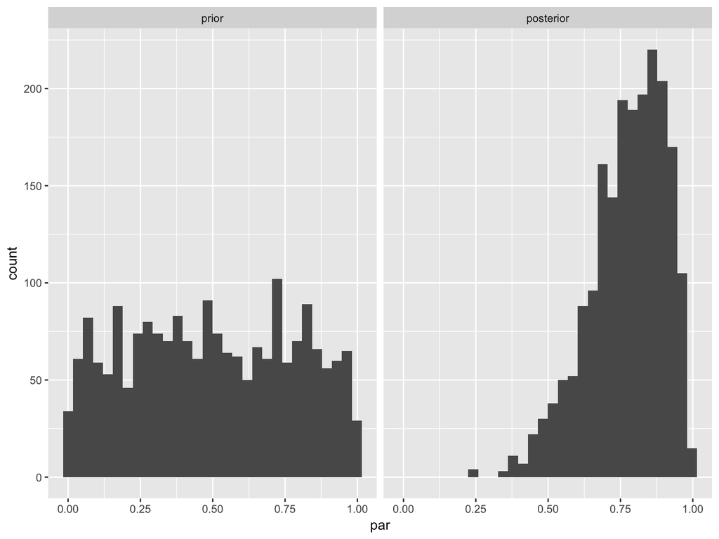

# Преимущества байесовского подхода:

- естественные вопросы: какова вероятность того, что параметр больше заданного порога?
- анализ сложных моделей: параметров больше, чем наблюдений!
- гибкость априорных распределений: можно взять любое!

# STAN хорош!

- взаимодействует со всем, что движется: R, python, julia, matlab, stata.
- подробная документация: $\ln(pages)\approx 6.36$
- даже официальных примеров куча: $\ln(examples) \approx 6.04$

В диалоговом режиме выбираем любой пример:

```r
model <- stan_demo()
```

# Когда жёлудь спелый, его всякая свинья слопает!

# Прямые конкуренты STAN:

- JAGS: хуже диагностика кода модели, медленная сходимость для высокой размерности
- WinBUGS: ещё и только под windows
- python + pymc: меньше пользователей
- julia + Klara, Mamba: пока совсем мало пользователей

# Наборы готовых моделей:

- R + MCMCpack, BMR, arm, bayesm, … > 100 пакетов

# Союзники STAN в R

- shinystan: графический анализ полученной выборки из апостериорного распределения
- rstanarm: набор заранее скомпилированных моделей STAN
- brms: конвертер иерархических моделей из формул R на язык STAN

# Регрессия с ограничением

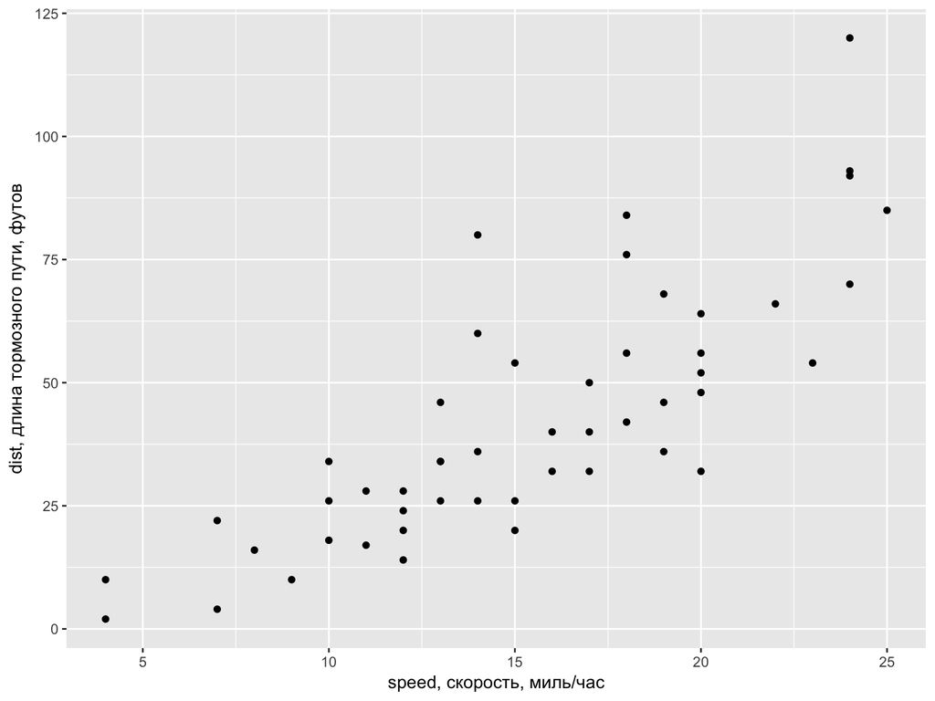

# Модель:

Данные:

$$dist_i = \beta_1 + \beta_2 speed_i + u_i$$

- $E(u_i)=0$, $Var(u_i)=\sigma^2$

Априорно:

- $\beta_1 \sim U(-\infty; +\infty)$
- $\beta_2 \sim Exp(\lambda = 0.1)$
- $\sigma \sim U[0; +\infty)$

# Код STAN

```r
model <- "
data {
  int N;
  int K;
  vector[N] y;
  matrix[N, K] X;
}
parameters {
  vector[K] beta;
  real<lower=0> sigma;
}
model {
  beta[2] ~ exponential(0.1);
  y ~ normal(X * beta, sigma);
}
"
```

# Что на графиках?

- сравнить априорное и апостериорное распределение
- наличие жёстких зависимостей на диаграмме рассеяния
- сходимость марковской цепи к апостериорному распределению

# Как вытащить априорное распределение?

Легко! Удалить из описания модели данные:

```r
model_prior <- "
parameters {
  real<lower=0> beta_2;
}
model {
  beta_2 ~ exponential(0.1);
}
"
```

Важно! Несобственные распределения будут расходиться! Используйте собственные :)

# Распределение до и после:

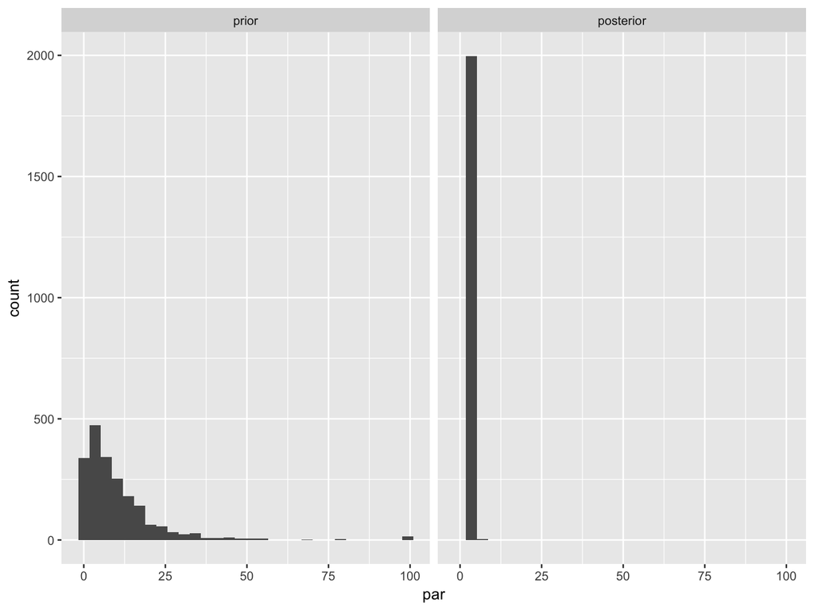

# Диаграммы рассеяния:

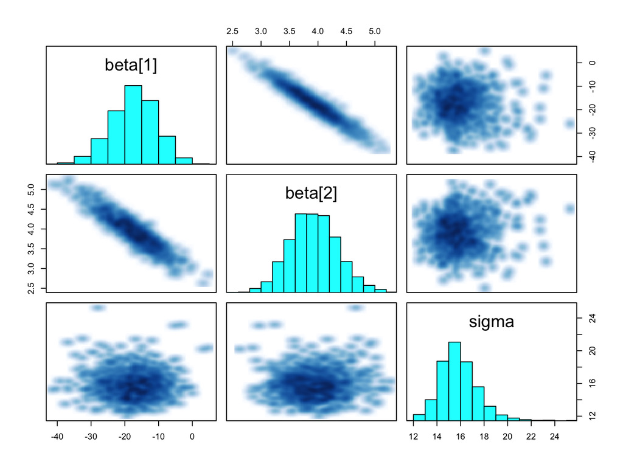

```r
pairs(fit, pars = c("beta[1]", "beta[2]", "sigma"))
```

# Графическая проверка сходимости:

```r
library("shinystan")
launch_shinystan(fit)
```

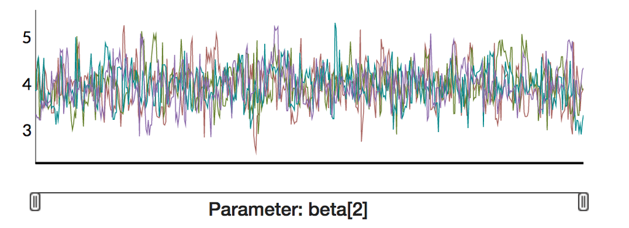

# Спасибо!

Ура, это почти последний слайд! :)

boris.demeshev@gmail.com

# Бонус: задача о шляпах

У старухи Шапокляк бесконечное количество занумерованных шляп. В каждую из них она кладёт бумажку со значением случайной величины $X_i$. Все $X_i \sim N(0;1)$ и независимы.

Гена и Чебурашка достают содержимое всех шляп кроме одной, по своему выбору. Их задача идеально точно угать величину в нераскрытой шляпе.

Какую вероятность угадывания они могут себе гарантировать?